# Natasha Velez

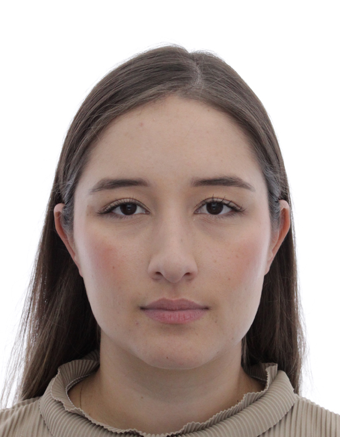

Vancouver, BC | natashavelezg12@gmail.com | 672-380-1824 |

[figure not shown]

linkedin.com/in/natasha-velez

## Professional Summary

Production Engineer specializing in Operations & Logistics and an MBA candidate at University Canada West. Over 5 years of experience in the textile industry leading initiatives across production, operations, inventory, and quality control. Proven track record improving processes, managing teams, and translating data insights into operational efficiency. Passionate about continuous improvement and technology-driven business transformation.

## Core Skills

Process Improvement

Operations Management

Inventory & Quality

Data Analysis & Reporting

Project Coordination

Analytical Thinking

Power BI

Problem Solving

## Professional Experience

**Quality Supervisor – Socks Division** — *Crystal S.A.S · Medellín, Colombia*  
Jun 2023 – Jan 2024  
- Supervised production quality across multiple lines.  
- Trained 30+ staff and ensured adherence to quality protocols.  
- Coordinated with production teams to meet specifications and on-time deliveries.

**Account Manager – Socks Product Development** — *Crystal S.A.S · Medellín, Colombia*  
May 2022 – Jun 2023  
- Served as main liaison between clients and production.  
- Managed end-to-end development cycles with 95% on-time completion.  
- Delivered client presentations and product updates.

**Product Development Specialist – Apparel & Seamless** — *Crystal S.A.S · Medellín, Colombia*  
Jul 2019 – May 2022  
- Streamlined product development workflows.  
- Reduced rework by 10% through prototyping improvements.  
- Shortened lead times by 8% via supplier coordination.

**Intern – Apparel Product Development** — *Crystal S.A.S · Medellín, Colombia*  
Jan 2019 – Jul 2019  
- Assisted in prototype testing and documentation.  
- Supported technical evaluations for apparel design.

## Education

**MBA (Master of Business Administration)** — *University Canada West, Canada*  
Expected May 2026

**Specialization in Operations & Logistics Management** — *Universidad EAFIT, Colombia*  
2021

**B.Sc. in Production Engineering** — *Universidad EAFIT, Colombia*  
2019

## Certifications & Training

- **Advanced Excel Certificate** — Universidad EAFIT (2018)